# Exploratory analysis of SFo Bike Share Data

## Background

I had participated in a Kaggle competition where the goal was to predict Bike share rentals per day given a small dataset by Kaggle. Details about that project can be found here: http://manishkurse.github.io/PythonProjects/BikeSharingDemand.html

This project aims to build on that experience by performing exploratory analysis on a larger dataset in the same domain in combination with a secondary dataset.

Tools used here: SQLite, Pandas, Numpy, scikit-learn

## Objectives

- Perform exploratory analysis on San Francisco bicycle share user trip data
- Can we find nearest SFo restaurants to bike stations? (Motivation: Can we get discount deals for users of these stations?)

Other questions (for future):

- Can we predict number of bikes and docks that will be available at each station?
- Can we predict inventory needed at stations based on a year's data?

Datasets: Bicycle share data: http://www.bayareabikeshare.com/datachallenge

San Francisco Restaurant data: https://data.sfgov.org/Economy-and-Community/Registered-Restaurants-in-SF/qwyj-4qec

Future projects: Can we recommend restaurants/cafes occur on the route of subscribed bikers?  
-- Motivation: This information could then be used to work with those businesses(restaurants/gyms/cafes) to give the bikers discounts. -- Data: In addition to the above data: ** this would need getting data from Yelp on these businesses, potentially implementing a recommendation engine ** and biking (if not available, then driving) routes obtained from Mapquest or Google Maps API between start and finish point of a bike path.

## Code

```python
import pandas as pd
import matplotlib.pyplot as plt
from datetime import datetime
import seaborn as sns
import numpy as np
import pygmaps
import sqlite3 as lite
import re
%matplotlib inline


read_from_csv = False
create_new_tables = False
read_from_sql = True
```

```python
# Read Data from CSV

def replace_camelcase_with_underscore(name):
    '''
    Taken from Stack Overflow:
    http://stackoverflow.com/questions/1175208/elegant-python-function-to-convert-camelcase-to-camel-case
    '''
    s1 = re.sub('(.)([A-Z][a-z]+)', r'\1_\2', name)
    return re.sub('([a-z0-9])([A-Z])', r'\1_\2', s1)

def clean_col_names(df):
    '''
    Replace space with underscore in column names
    '''
    df.columns = [name.lstrip() for name in df.columns.tolist()]
    df.columns = [name.rstrip() for name in df.columns.tolist()]
    df.columns = [name.replace(' ','') for name in df.columns.tolist()]
    df.columns = [name.replace('_','') for name in df.columns.tolist()]
    df.columns = [replace_camelcase_with_underscore(name) for name in df.columns.tolist()]
    return df

if read_from_csv:
    # Read data from csv files
    trip_df = pd.read_csv("Datasets/201402_trip_data.csv", nrows=None)
    weath_df = pd.read_csv("Datasets/201402_weather_data.csv", nrows=None)
    stn_df = pd.read_csv("Datasets/201402_station_data.csv", nrows=None)
    res_df = pd.read_csv("Datasets/Registered_Restaurants_in_SF.csv", nrows=None)
    rebal_df = pd.read_csv("Datasets/201402_rebalancing_data.csv", nrows=None)
    weath_df = weath_df.rename(columns = {'zip' : 'Zip'})

    # Data cleaning and feature engineering
    # Clean column names
    dfs = [trip_df, weath_df, stn_df, res_df, rebal_df]
    for idx,df in enumerate(dfs):
        dfs[idx] = clean_col_names(dfs[idx])

    trip_df2 = pd.read_csv("Datasets/201408_trip_data.csv", nrows=None)
    weath_df2 = pd.read_csv("Datasets/201408_weather_data.csv", nrows=None)
    stn_df2 = pd.read_csv("Datasets/201408_station_data.csv", nrows=None)
    rebal_df2 = pd.read_csv("Datasets/201408_rebalancing_data.csv", nrows=None)

    #Rename column in trip_df2
    trip_df2 = trip_df2.rename(columns = {"Subscriber Type": "Subscription Type"})
    weath_df2 = weath_df2.rename(columns = {'PDT' : 'Date'})

    dfs = [trip_df2, weath_df2, stn_df2, rebal_df2]
    for idx,df in enumerate(dfs):
        dfs[idx] = clean_col_names(dfs[idx])

    # Combine two sets of dataframes to one
    trip_df = trip_df.append (trip_df2, ignore_index = True)
    weath_df = weath_df.append (weath_df2, ignore_index=True)
    stn_df = stn_df.append (stn_df2, ignore_index=True)
    rebal_df = rebal_df.append (rebal_df2, ignore_index=True)


    # Remove outliers. Outliers defined as values greater than 99.5th percentile
    maxVal = np.percentile(trip_df['Duration'],99.5)
    trip_df = trip_df[trip_df['Duration'] <= maxVal]

    # Extract date, month, hour of start
    trip_df['Start_day'] = trip_df['Start_Date'].map(lambda x:(datetime.strptime(x, "%m/%d/%Y %H:%M")).day)
    trip_df['Start_month'] = trip_df['Start_Date'].map(lambda x:(datetime.strptime(x, "%m/%d/%Y %H:%M")).month)
    trip_df['Start_hour'] = trip_df['Start_Date'].map(lambda x:(datetime.strptime(x, "%m/%d/%Y %H:%M")).hour)

    # Clean the restaurant table to extract the longitude and latitude information
    geo_loc = res_df['Business_Location'].apply(lambda x: x.split('(')[1])
    res_df['rest_lat'] = geo_loc.apply(lambda x: np.float(x.split(',')[0]))
    res_df['rest_long']= geo_loc.apply(lambda x: np.float(x.split(',')[1][:-1]))
```

```python
# Create SQL table
def create_table(df,table_name,con):
    df.to_sql(table_name,con,if_exists='replace')
    return 1

# Write csv data to SQL
if create_new_tables:
    table_names = ["trip_info","weather","station","restaurant","rebal"]
    dfs = [trip_df,weath_df,stn_df,res_df,rebal_df]
    con = lite.connect("sfo_bike.db")

    for idx,df in enumerate(dfs):
        create_table(df,table_names[idx],con)
```

```python
if read_from_sql == True:
    con = lite.connect("sfo_bike.db")
    query_res = '''
            SELECT Location_ID, Zip_Code, rest_lat,rest_long
            FROM restaurant;
            '''

    query_trip = '''
            SELECT Trip_ID , Duration , Start_Terminal, Start_Date,
                   End_Terminal , Subscription_Type ,
                   Zip_Code , Start_day , Start_month , Start_hour
            FROM trip_info;
            '''

    query_stn = '''
            SELECT stationid , lat , long , dockcount
            FROM station;
            '''
    query_reb = '''
            SELECT stationid , bikesavailable , docksavailable, time
            FROM rebal
            LIMIT 10;
            '''
    query_weat  = '''
            SELECT stationid , bikesavailable , docksavailable, time
            FROM weather
            '''

    res_df = pd.read_sql_query(query_res, con, index_col=None, coerce_float=True, \
                           params=None, parse_dates=None, chunksize=None)

    trip_df = pd.read_sql_query(query_trip, con, index_col=None, coerce_float=True, \
                           params=None, parse_dates=None, chunksize=None)

    stn_df = pd.read_sql_query(query_stn, con, index_col=None, coerce_float=True, \
                           params=None, parse_dates=None, chunksize=None)
    rebal_df = pd.read_sql_query(query_reb, con, index_col=None, coerce_float=True, \
                           params=None, parse_dates=None, chunksize=None)
else:

    # Only a subsets of the data frames are sufficient for our analysis
    res_df = res_df[['Location_ID','Zip_Code','rest_lat','rest_long']]
    trip_df = trip_df[['Trip_ID','Duration','Start_Terminal','End_Terminal','Subscription_Type','Zip_Code','Start_day','Start_month','Start_hour']]
    stn_df = stn_df[['station_id','lat','long','dockcount']]
```

```python
def replace_hyp_with_bck(ser):
    vals = [strg.replace('-','/') for strg in ser.values]
    return vals

rebal_df['time'] = replace_hyp_with_bck(rebal_df['time'])
```

## Feature engineering

```python
trip_df['day_of_week'] = trip_df['Start_Date'].map(lambda x:(datetime.strptime(x, "%m/%d/%Y %H:%M")).weekday())

rebal_df['Day'] = rebal_df['time'].map(lambda x:(datetime.strptime(x, "%Y/%m/%d %H:%M:%S")).day)
rebal_df['month'] = rebal_df['time'].map(lambda x:(datetime.strptime(x, "%Y/%m/%d %H:%M:%S")).month)
rebal_df['hour'] = rebal_df['time'].map(lambda x:(datetime.strptime(x, "%Y/%m/%d %H:%M:%S")).hour)

# weath_df['Day'] = weath_df['Date'].map(lambda x:(datetime.strptime(x, "%m/%d/%Y")).day)
# weath_df['Day'] = weath_df['Date'].map(lambda x:(datetime.strptime(x, "%m/%d/%Y")).month)

bike_avail = rebal_df.groupby(['month','Day','hour'])['bikesavailable'].min()
dock_avail = rebal_df.groupby(['month','Day','hour'])['docksavailable'].min()
```

```python
def get_crowfly_distance(lat1, lon1, lat2, lon2):
    '''
    Function to calculate distance based on latitude,longitude of 2 places
    using Haversine formula
    http://andrew.hedges.name/experiments/haversine/
    '''

    lon1 = lon1*np.pi/180
    lat1 = lat1*np.pi/180
    lon2 = lon2*np.pi/180
    lat2 = lat2*np.pi/180

    dlon = lon2 - lon1
    dlat = lat2 - lat1

    R = 3961 # miles
    a = (np.sin(dlat/2))**2 + np.cos(lat1) * np.cos(lat2) * (np.sin(dlon/2))**2
    c = 2 * np.arctan2( np.sqrt(a), np.sqrt(1-a) )
    d = R * c
    return d


# Update the trip data table with the latitudes and longitudes of start and end
trip_df = trip_df.rename(columns = {'Start_Terminal': 'stationid'})
trip_df = pd.merge(trip_df,stn_df[['lat','long','stationid']], \
                   how = 'left', on=['stationid'])
trip_df = trip_df.drop_duplicates()

trip_df = trip_df.rename(columns = {'lat':'Start_lat','long' : 'Start_long','stationid': 'Start_Terminal'})
# trip_df.drop('station_id', axis=1, inplace=True)
trip_df = trip_df.rename(columns = {'End_Terminal': 'stationid'})
trip_df = pd.merge(trip_df,stn_df[['lat','long','stationid']], \
                    how = 'left', on=['stationid'])
trip_df = trip_df.drop_duplicates()
trip_df = trip_df.rename(columns = {'stationid': 'End_Terminal','lat':'End_lat','long' : 'End_long'})

trip_df['Distance'] = get_crowfly_distance(trip_df['Start_lat'], trip_df['Start_long'], trip_df['End_lat'], trip_df['End_long'])
```

## Exploratory Data Analysis

```python
# Defining a color pattern based on Tableau's color code
colrcode = [(31, 119, 180), (255, 127, 14),\
             (44, 160, 44), (214, 39, 40), \
             (148, 103, 189),  (140, 86, 75), \
             (227, 119, 194), (127, 127, 127), \
             (188, 189, 34), (23, 190, 207)]

for i in range(len(colrcode)):
    r, g, b = colrcode[i]
    colrcode[i] = (r / 255., g / 255., b / 255.)
```

```
Peak on Day 0 occurs on 800 hours
Peak on Day 1 occurs on 800 hours
Peak on Day 2 occurs on 800 hours
Peak on Day 3 occurs on 800 hours
Peak on Day 4 occurs on 800 hours
Peak on Day 5 occurs on 1200 hours
Peak on Day 6 occurs on 1500 hours
Peak on Day 0 occurs at 1600 hours
Peak on Day 1 occurs at 1700 hours
Peak on Day 2 occurs at 1700 hours
Peak on Day 3 occurs at 1500 hours
Peak on Day 4 occurs at 1300 hours
Peak on Day 5 occurs at 1400 hours
Peak on Day 6 occurs at 1500 hours
```

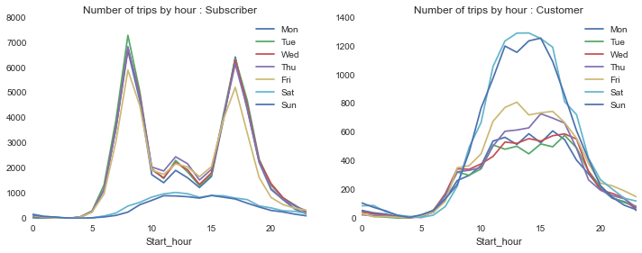

```python
# Understanding the number of trips based on weekday.

fig,axes = plt.subplots(figsize=(12, 4), nrows=1, ncols=2)

a = trip_df[trip_df['Subscription_Type'] == 'Subscriber'].groupby(['day_of_week','Start_hour'])['Trip_ID'].count()
days = ['Mon','Tue','Wed','Thu','Fri','Sat','Sun']

plt.sca(axes[0])

for i in range(7):
    x = a[i].plot(label = days[i])
    print('Peak on Day {0} occurs on {1}00 hours'.format(i,np.argmax(a[i])))
plt.title('Number of trips by hour : Subscriber')
plt.legend()

a = trip_df[trip_df['Subscription_Type'] == 'Customer'].groupby(['day_of_week','Start_hour'])['Trip_ID'].count()
days = ['Mon','Tue','Wed','Thu','Fri','Sat','Sun']

plt.sca(axes[1])
for i in range(7):
    x = a[i].plot(label = days[i])
    print('Peak on Day {0} occurs at {1}00 hours'.format(i,np.argmax(a[i])))
plt.title('Number of trips by hour : Customer')
plt.legend()
```

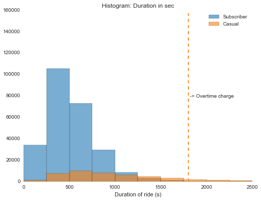

```python
plt.figure(figsize = [8,6])
h = plt.hist(trip_df[trip_df['Subscription_Type'] == 'Subscriber']['Duration'].values,\
             range = [0,2500],color = colrcode[0],alpha = .6, label = 'Subscriber')

plt.plot([1800,1800],[0,float(trip_df.shape[0]/2)],color = colrcode[1],linestyle = '--')
plt.text(1820,float(trip_df.shape[0]/4),'-> Overtime charge')

h = plt.hist(trip_df[trip_df['Subscription_Type'] == 'Customer']['Duration'].values,\
             range = [0,2500],color = colrcode[1],alpha = .6, label = 'Casual')
plt.title('Histogram: Duration in sec')
plt.xlabel('Duration of ride (s)')
plt.legend()
```

```python
val = trip_df[(trip_df['Subscription_Type'] == 'Customer') & (trip_df['Duration']>1800)]['Duration'].count()/\
    float(trip_df[(trip_df['Subscription_Type'] == 'Customer')]['Duration'].count())
print("{0}% of causal customers pay overtime fee! ".format(np.round(val*100,0)))

val = trip_df[(trip_df['Subscription_Type'] == 'Subscriber') & (trip_df['Duration']>1800)]['Duration'].count()/\
    float(trip_df[(trip_df['Subscription_Type'] == 'Subscriber')]['Duration'].count())
print("{0}% of subscribers pay overtime fee! ".format(np.round(val*100,0)))
```

```
28.0% of causal customers pay overtime fee!
1.0% of subscribers pay overtime fee!
```

- As is seen in the histogram above, most rides use it for below 30 minutes above which there is an overtime fee. Subscribers keep their commute shorter.
- Quite a large number of casual customers end up paying overtime fee! (28.0%)

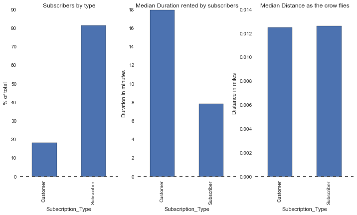

```python
# Understanding How Metrics are different based on Subscription Type
num_sub = trip_df.groupby('Subscription_Type')['Duration'].count()
dur_sub = trip_df.groupby('Subscription_Type')['Duration'].median()/60

dis_sub = trip_df.groupby('Subscription_Type')['Distance'].median()/60

fig,axes = plt.subplots(figsize=(12, 6), nrows=1, ncols=3)
plt.sca(axes[0])
num_sub = num_sub/np.sum(num_sub.values)*100
num_sub.plot(kind = 'bar')
plt.ylabel('% of total')
plt.title('Subscribers by type')
plt.sca(axes[1])
dur_sub.plot(kind = 'bar')
plt.ylabel('Duration in minutes')
plt.title('Median Duration rented by subscribers')
plt.sca(axes[2])
dis_sub.plot(kind = 'bar')
plt.ylabel('Distance in miles')
plt.title('Median Distance as the crow flies')
```

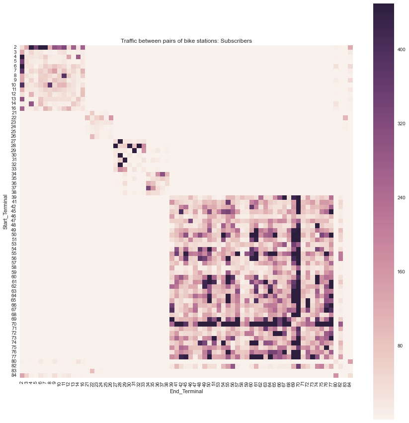

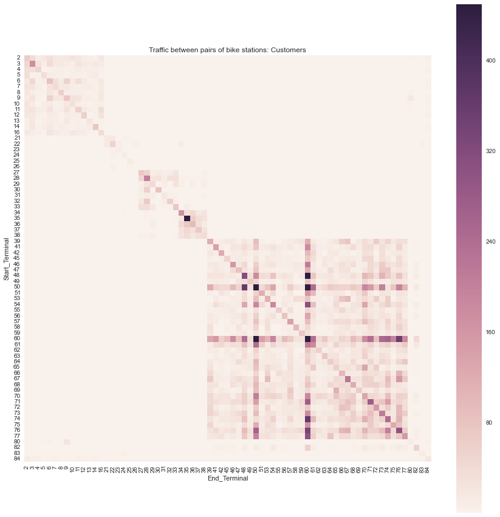

```python
# Examining traffic between stations

counts_per_endStation = trip_df[trip_df['Subscription_Type'] == 'Subscriber'].groupby(['Start_Terminal','End_Terminal'])['Trip_ID'].count()
counts_per_endStation  = counts_per_endStation.unstack()
plt.figure(figsize = (15,15))
h = sns.heatmap(counts_per_endStation ,linewidths=0, square=True , vmax=450)
h = plt.xticks(rotation='vertical')
h= plt.yticks(rotation='horizontal')
plt.title('Traffic between pairs of bike stations: Subscribers')
plt.savefig('HeatMap_StationUsage.png')

counts_per_endStation = trip_df[trip_df['Subscription_Type'] == 'Customer'].groupby(['Start_Terminal','End_Terminal'])['Trip_ID'].count()
counts_per_endStation  = counts_per_endStation.unstack()
plt.figure(figsize = (15,15))
h = sns.heatmap(counts_per_endStation ,linewidths=0, square=True , vmax=450)
h = plt.xticks(rotation='vertical')
h= plt.yticks(rotation='horizontal')
plt.title('Traffic between pairs of bike stations: Customers')
plt.savefig('HeatMap_StationUsage_Customer.png')
```

```python
# Determine nearest neighbor restaurants to each of the stations
k = 5 # num nearest neighbors
from sklearn.neighbors import NearestNeighbors
a = np.matrix([res_df.rest_lat.values,res_df.rest_long.values])
b = a.transpose()
samples = b
neigh = NearestNeighbors(k, radius = 1)

# Train the nearest neighbor algorithm
neigh.fit(samples)

lat_lon = np.matrix([stn_df.lat.values,stn_df.long.values])
lat_lon = lat_lon.transpose()



mymap = pygmaps.maps(37.7858345,-122.4059035,15)
for i in range(res_df.shape[0]):
    mymap.addpoint(res_df.rest_lat[i],res_df.rest_long[i], "#DBDBD6") # red "#FF0000 for red Green "#00FF00"

for i in range(stn_df.shape[0]):
    mymap.addpoint(stn_df.lat[i],stn_df.long[i], "#0000FF") # red "#FF0000 for red Green "#00FF00"
    nb = neigh.kneighbors(lat_lon[i], k,return_distance=False)
    for count in range(k):
        mymap.addpoint(samples[nb[0][count],0],samples[nb[0][count],1], "#FF0000") # red "#FF0000 for red Green "#00FF00"
mymap.draw('./mymap.html')
```

```python
import webbrowser
new = 2 # open in a new tab, if possible
url = "./mymap.html"
h = webbrowser.open(url,new=new)
```

Insight gained:

[output not shown]

```python
# no_bikes = rebal_df[rebal_df['bikes_available']==0]['station_id'].value_counts()
# plt.figure(figsize=(8,6))
# h = plt.bar(no_bikes.keys().values,no_bikes.values)
```